# WeatherPy

# My Analysis:

The results of the latitude vs. cloudiness indicates a weak relationship.

## Latitude vs. Wind Speed Plot

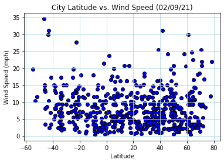

```python
plt.scatter(weatherpy_dict["Lat"],weatherpy_dict["Wind Speed"],edgecolors="black",facecolors="blue")
plt.grid (b=True,which="major",axis="both",linestyle="-",color="lightblue")
plt.title("City Latitude vs. Wind Speed (02/09/21)")
plt.xlabel("Latitude")
plt.ylabel("Wind Speed (mph)")
plt.savefig('../output_data/lat_vs_windspeed_toussaint.png')
plt.show()
```

# My Analysis:

## Linear Regression

```python
# Create Northern and Southen divider

northern_hemisphere = weatherpy_dict.loc[weatherpy_dict["Lat"] >= 0]
southern_hemisphere = weatherpy_dict.loc[weatherpy_dict["Lat"] < 0]
```

#### Northern Hemisphere - Max Temp vs. Latitude Linear Regression

```
The r-squared is: 0.7811314869973106
```

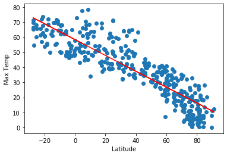

```python
# Print out the r-squared value along with the plot.
x_values = northern_hemisphere["Max Temp"]
y_values = northern_hemisphere["Lat"]
(slope, intercept, rvalue, pvalue, stderr) = linregress(x_values, y_values)
regress_values = x_values * slope + intercept
line_eq = "y = " + str(round(slope,2)) + "x + " + str(round(intercept,2))

# Creating linear graph
plt.scatter(x_values,y_values)
plt.plot(x_values,regress_values,"r-")
plt.annotate(line_eq,(-40,0),fontsize=15,color="red")
plt.xlabel('Latitude')
plt.ylabel('Max Temp')

print(f"The r-squared is: {rvalue**2}")
plt.show()
```

# My Analysis:

The results of the Northern Hemisphere by Max Temp vs. Latitude displays a negative relationship but strong correlation.

#### Southern Hemisphere - Max Temp vs. Latitude Linear Regression

```
The r-squared is: 0.2073676266288405
```

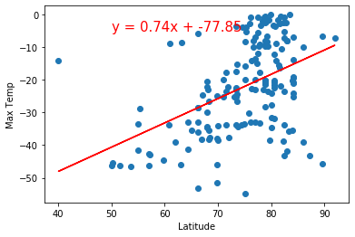

```python
# Print out the r-squared value along with the plot.
x_values = southern_hemisphere["Max Temp"]
y_values = southern_hemisphere["Lat"]
(slope, intercept, rvalue, pvalue, stderr) = linregress(x_values, y_values)
regress_values = x_values * slope + intercept
line_eq = "y = " + str(round(slope,2)) + "x + " + str(round(intercept,2))
plt.scatter(x_values,y_values)
plt.plot(x_values,regress_values,"r-")
plt.annotate(line_eq,(50,-5),fontsize=15,color="red")
plt.xlabel('Latitude')
plt.ylabel('Max Temp')
print(f"The r-squared is: {rvalue**2}")
plt.show()
```

# My Analysis:

The results of the Southern Hemisphere by Max Temp vs. Latitude shows a positive relationship by direction but weak correlction.

#### Northern Hemisphere - Humidity (%) vs. Latitude Linear Regression

```
The r-squared is: 0.06463979447221659
```

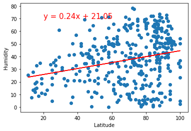

```python
# Print out the r-squared value along with the plot.
x_values = northern_hemisphere["Humidity"]
y_values = northern_hemisphere["Lat"]
(slope, intercept, rvalue, pvalue, stderr) = linregress(x_values, y_values)
regress_values = x_values * slope + intercept
line_eq = "y = " + str(round(slope,2)) + "x + " + str(round(intercept,2))
plt.scatter(x_values,y_values)
plt.plot(x_values,regress_values,"r-")
plt.annotate(line_eq,(20,70),fontsize=15,color="red")
plt.xlabel('Latitude')
plt.ylabel('Humidity')
print(f"The r-squared is: {rvalue**2}")
plt.show()
```

# My Analysis:

#### Southern Hemisphere - Humidity (%) vs. Latitude Linear Regression

```
The r-squared is: 0.18099079938837997
```

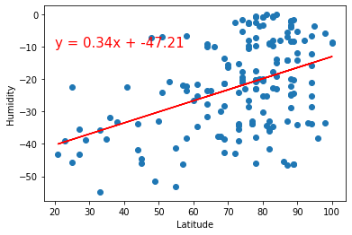

```python
# Print out the r-squared value along with the plot.
x_values = southern_hemisphere["Humidity"]
y_values = southern_hemisphere["Lat"]
(slope, intercept, rvalue, pvalue, stderr) = linregress(x_values, y_values)
regress_values = x_values * slope + intercept
line_eq = "y = " + str(round(slope,2)) + "x + " + str(round(intercept,2))
plt.scatter(x_values,y_values)
plt.plot(x_values,regress_values,"r-")
plt.annotate(line_eq,(20,-10),fontsize=15,color="red")
plt.xlabel('Latitude')
plt.ylabel('Humidity')
print(f"The r-squared is: {rvalue**2}")
plt.show()
```

# My Analysis:

The results of the Southern Hemisphere by Humidity (%) vs. Latitude shows a positive relationship by direction but very weak correalation.

#### Northern Hemisphere - Cloudiness (%) vs. Latitude Linear Regression

```
The r-squared is: 0.008061140350962821
```

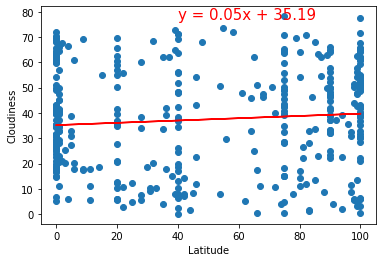

```python
# Print out the r-squared value along with the plot.
x_values = northern_hemisphere["Cloudiness"]
y_values = northern_hemisphere["Lat"]
(slope, intercept, rvalue, pvalue, stderr) = linregress(x_values, y_values)
regress_values = x_values * slope + intercept
line_eq = "y = " + str(round(slope,2)) + "x + " + str(round(intercept,2))
plt.scatter(x_values,y_values)
plt.plot(x_values,regress_values,"r-")
plt.annotate(line_eq,(40,77),fontsize=15,color="red")
plt.xlabel('Latitude')
plt.ylabel('Cloudiness')
print(f"The r-squared is: {rvalue**2}")
plt.show()
```

# My Analysis:

#### Southern Hemisphere - Cloudiness (%) vs. Latitude Linear Regression

```
The r-squared is: 0.18309852837106574
```

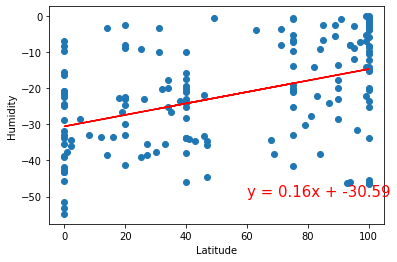

```python
# Print out the r-squared value along with the plot.
x_values = southern_hemisphere["Cloudiness"]
y_values = southern_hemisphere["Lat"]
(slope, intercept, rvalue, pvalue, stderr) = linregress(x_values, y_values)
regress_values = x_values * slope + intercept
line_eq = "y = " + str(round(slope,2)) + "x + " + str(round(intercept,2))
plt.scatter(x_values,y_values)
plt.plot(x_values,regress_values,"r-")
plt.annotate(line_eq,(60,-50),fontsize=15,color="red")
plt.xlabel('Latitude')
plt.ylabel('Humidity')
print(f"The r-squared is: {rvalue**2}")
plt.show()
```

# My Analysis:

The results of the Southern Hemisphere by Cloudiness (%) vs. Latitude shows a positive relationship by direction but very weak correlation.

#### Northern Hemisphere - Wind Speed (mph) vs. Latitude Linear Regression

```
The r-squared is: 0.0015545470413693087
```

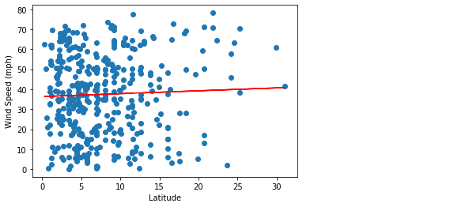

```python
# Print out the r-squared value along with the plot.
x_values = northern_hemisphere["Wind Speed"]
y_values = northern_hemisphere["Lat"]
(slope, intercept, rvalue, pvalue, stderr) = linregress(x_values, y_values)
regress_values = x_values * slope + intercept
line_eq = "y = " + str(round(slope,2)) + "x + " + str(round(intercept,2))
plt.scatter(x_values,y_values)
plt.plot(x_values,regress_values,"r-")
plt.annotate(line_eq,(40,77),fontsize=15,color="red")
plt.xlabel('Latitude')
plt.ylabel('Wind Speed (mph)')
print(f"The r-squared is: {rvalue**2}")
plt.show()
```

# My Analysis:

#### Southern Hemisphere - Wind Speed (mph) vs. Latitude Linear Regression

```
The r-squared is: 0.09386539794054168
```

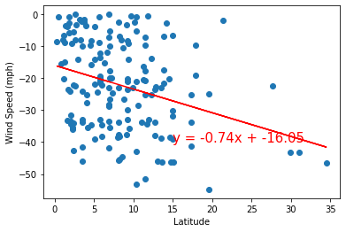

```python
# Print out the r-squared value along with the plot.
x_values = southern_hemisphere["Wind Speed"]
y_values = southern_hemisphere["Lat"]
(slope, intercept, rvalue, pvalue, stderr) = linregress(x_values, y_values)
regress_values = x_values * slope + intercept
line_eq = "y = " + str(round(slope,2)) + "x + " + str(round(intercept,2))
plt.scatter(x_values,y_values)
plt.plot(x_values,regress_values,"r-")
plt.annotate(line_eq,(15,-40),fontsize=15,color="red")
plt.xlabel('Latitude')
plt.ylabel('Wind Speed (mph)')
print(f"The r-squared is: {rvalue**2}")
plt.show()
```

# My Analysis:

The results of the Southern Hemisphere by Wind Speed (mph) vs. Latitude shows a negative relationship by direction but very weak correlation.